# BS Ice Kohonen analysis - Multivariate (ICE and MSLP)

Using 8day averaged ice concentration data (S.Salo) Choose a select group of locations on grid. (every 4th point)

```r
dp = read.csv('/Users/bell/in_and_outbox/2017/stabeno/Ice_kohonen/coords_subset_4pt_noland.asc2',header=TRUE,sep='')
```

Using NCEP Reanalysis II mean-daily 2m air temperature on four grid points (p1-181.875,65.712 p2-193.125,65.712 p3-181.875,58.0939 p4-193.125,58.0939) - Temp does not seem to provide more guidance. *Initial runs had a datapoint over land, drop the lat of P1,P2 to 63.8079* –> .v2 data p1 - 181.875,63.8079 p2 - 193.125,63.8079 p3 - 181.875,58.0939 p4 - 193.125,58.0939

Equivalent 8day averages are made (with the exception of the last chunk of the year. Salo has 359-001, this is 359-365)

1979 DJ - 2017 DJ Both files are on same time grid (which is the list of files from the DJ subset) ‘coords_ncep_temp.asc2’

‘NCEP_mslp_grid.txt’

Stagger MSLP and Temperature so that it leads ICE by one 8day period

```r
library(kohonen)
ice_data = data.matrix(read.csv('/Users/bell/in_and_outbox/2017/stabeno/Ice_kohonen/1979-2016_4pt_noland_DF.asc')) / 100.
temp_noscale = data.matrix(read.csv('/Users/bell/in_and_outbox/2017/stabeno/Ice_kohonen/1979-2017_NCEP_2mtemp_p8d.v2.csv'))
temp_data = scale(temp_noscale,center=TRUE,scale=TRUE)
mslp_noscale = data.matrix(read.csv('/Users/bell/in_and_outbox/2017/stabeno/Ice_kohonen/1979-2017_NCEPmslp_p8d.csv'))
mslp_mean <- colMeans(mslp_noscale)
mslp_anom = scale(mslp_noscale,center=TRUE,scale=FALSE)
mslp_data = scale(mslp_noscale,center=TRUE,scale=TRUE)
bering_data <- list(ice = ice_data, temperature = temp_data, mslp = mslp_data)
```

With variables read in, run multivariate SOM analysis. Weight ice-70% and temp-0% and mslp-30%

```r
set.seed(7)
ssom.BS <- supersom(bering_data,grid=somgrid(3,4,"hexagonal"),user.weights=c(0.70,0.3),whatmap=c(1,3),maxNA.fraction=1,rlen=1000)
summary(ssom.BS)
```

```
SOM of size 3x4 with a hexagonal topology and a bubble neighbourhood function.
Training data included of 304 objects
The number of layers is 3, of which 2 have been used in training.
Mean distance to the closest unit in the map: 4.86034
```

```r
map(ssom.BS)
```

[output not shown]

[output cut: 37 more lines]

```r
getCodes(ssom.BS)
```

[output not shown]

[output cut: 229 more lines]

[output not shown]

```r
coolBlueHotRed <- function(n, alpha = 1) {rainbow(n, end=4/6, alpha=alpha)[n:1]}
colfunc <- colorRampPalette(c("blue","white","red"))
prange = c(-25,25)
```

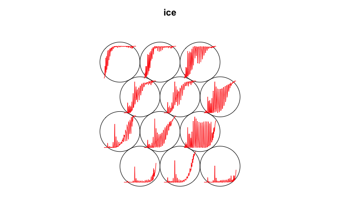

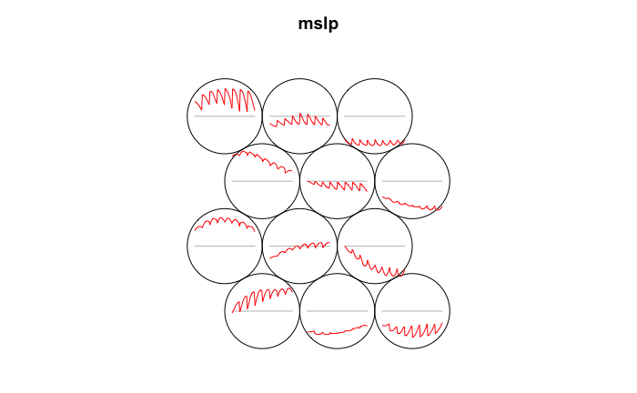

```r
plot(ssom.BS,"codes",codeRendering="lines")
```

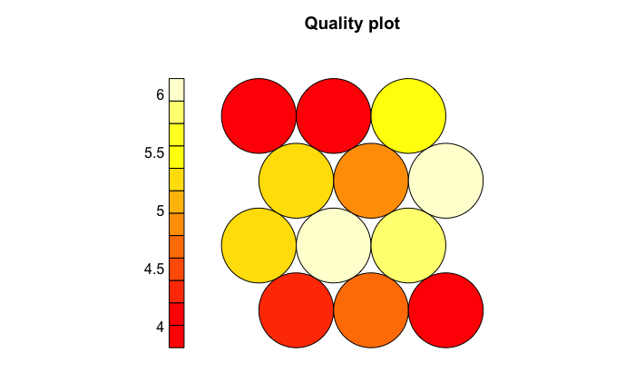

```r
plot(ssom.BS,"quality")
```

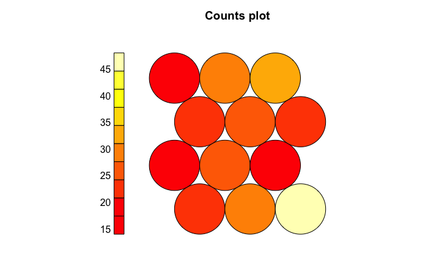

```r
plot(ssom.BS,"counts")
```

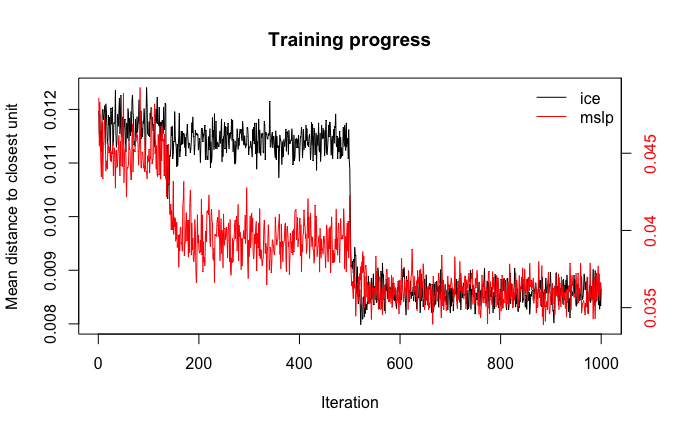

```r
plot(ssom.BS,"changes")
```

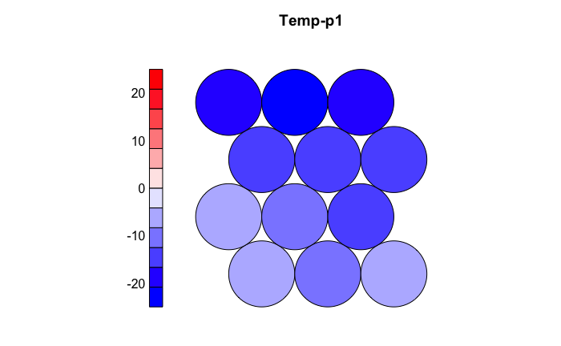

```r
#plot(ssom.BS, type="dist.neighbours")
var_unscaled <- aggregate(as.numeric(temp_noscale[,1]), by=list(ssom.BS$unit.classif), FUN=mean, simplify=TRUE)[,2]
plot(ssom.BS, type="property",property=var_unscaled,main='Temp-p1',palette.name = colfunc,zlim=prange)
```

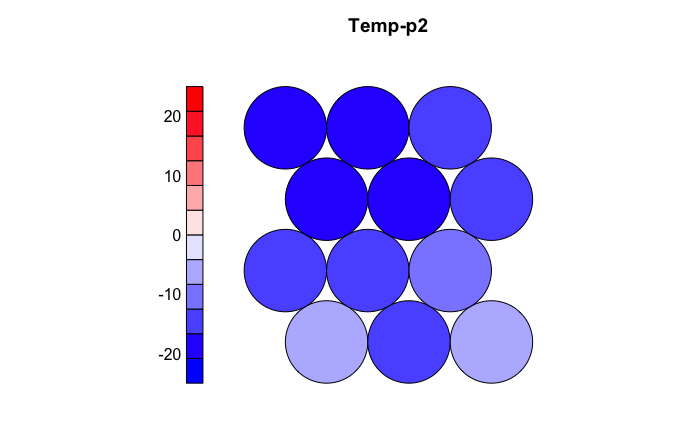

```r
var_unscaled <- aggregate(as.numeric(temp_noscale[,2]), by=list(ssom.BS$unit.classif), FUN=mean, simplify=TRUE)[,2]
plot(ssom.BS, type="property",property=var_unscaled,main='Temp-p2',palette.name = colfunc,zlim=prange)
```

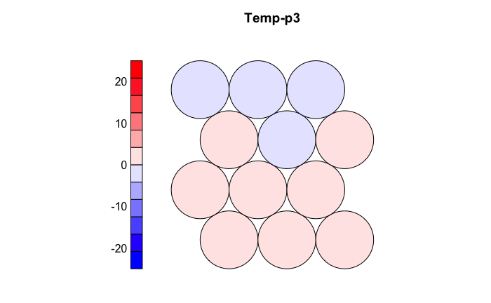

```r
var_unscaled <- aggregate(as.numeric(temp_noscale[,3]), by=list(ssom.BS$unit.classif), FUN=mean, simplify=TRUE)[,2]
plot(ssom.BS, type="property",property=var_unscaled,main='Temp-p3',palette.name = colfunc,zlim=prange)
```

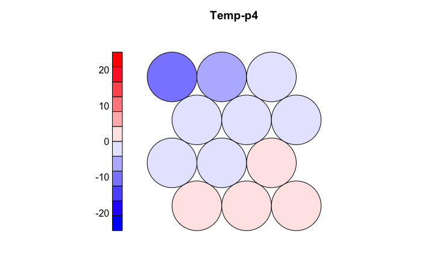

```r
var_unscaled <- aggregate(as.numeric(temp_noscale[,4]), by=list(ssom.BS$unit.classif), FUN=mean, simplify=TRUE)[,2]
plot(ssom.BS, type="property",property=var_unscaled,main='Temp-p4',palette.name = colfunc,zlim=prange)
```

```r
var_unscaled <- aggregate((mslp_noscale), by=list(ssom.BS$unit.classif), FUN=mean, simplify=TRUE)
```